# Machine Learning Workflow: MLP (Heart Data)

Biostat 203B

Author

Dr. Hua Zhou @ UCLA

Published

February 27, 2024

## 1 Setup

Display system information for reproducibility.

**R**

**Python**

```python
import IPython
print(IPython.sys_info())
```

```
{'commit_hash': '8b1204b6c',
 'commit_source': 'installation',
 'default_encoding': 'utf-8',
 'ipython_path': '/opt/venv/lib/python3.10/site-packages/IPython',
 'ipython_version': '8.21.0',
 'os_name': 'posix',
 'platform': 'Linux-6.6.12-linuxkit-aarch64-with-glibc2.35',
 'sys_executable': '/opt/venv/bin/python',
 'sys_platform': 'linux',
 'sys_version': '3.10.12 (main, Nov 20 2023, 15:14:05) [GCC 11.4.0]'}
```

## 2 Overview

[figure not shown]

We illustrate the typical machine learning workflow for multi-layer perceptron (MLP) using the `Heart` data set. The outcome is `AHD` (`Yes` or `No`).

1. Initial splitting to test and non-test sets.
2. Pre-processing of data: dummy coding categorical variables, standardizing numerical variables, imputing missing values, …
3. Tune the MLP algorithm using 5-fold cross-validation (CV) on the non-test data.
4. Choose the best model by CV and refit it on the whole non-test data.
5. Final classification on the test data.

## 3 Heart data

The goal is to predict the binary outcome `AHD` (`Yes` or `No`) of patients.

**R**

```r
# Load libraries
library(GGally)
library(gtsummary)
library(keras)
library(tidyverse)
library(tidymodels)

# Load the `Heart.csv` data.
Heart <- read_csv("Heart.csv") |>
  # first column is patient ID, which we don't need
  select(-1) |>
  # RestECG is categorical with value 0, 1, 2
  mutate(RestECG = as.character(RestECG)) |>
  print(width = Inf)
```

```
# A tibble: 303 × 14
     Age   Sex ChestPain    RestBP  Chol   Fbs RestECG MaxHR ExAng Oldpeak Slope
   <dbl> <dbl> <chr>         <dbl> <dbl> <dbl> <chr>   <dbl> <dbl>   <dbl> <dbl>
 1    63     1 typical         145   233     1 2         150     0     2.3     3
 2    67     1 asymptomatic    160   286     0 2         108     1     1.5     2
 3    67     1 asymptomatic    120   229     0 2         129     1     2.6     2
 4    37     1 nonanginal      130   250     0 0         187     0     3.5     3
 5    41     0 nontypical      130   204     0 2         172     0     1.4     1
 6    56     1 nontypical      120   236     0 0         178     0     0.8     1
 7    62     0 asymptomatic    140   268     0 2         160     0     3.6     3
 8    57     0 asymptomatic    120   354     0 0         163     1     0.6     1
 9    63     1 asymptomatic    130   254     0 2         147     0     1.4     2
10    53     1 asymptomatic    140   203     1 2         155     1     3.1     3
      Ca Thal       AHD
   <dbl> <chr>      <chr>
 1     0 fixed      No
 2     3 normal     Yes
 3     2 reversable Yes
 4     0 normal     No
 5     0 normal     No
 6     0 normal     No
 7     2 normal     Yes
 8     0 normal     No
 9     1 reversable Yes
10     0 reversable Yes
# ℹ 293 more rows
```

```r
# Numerical summaries stratified by the outcome `AHD`.
Heart |> tbl_summary(by = AHD)
```

| **Characteristic** | **No**, N = 164<sup>1</sup> | **Yes**, N = 139<sup>1</sup> |
| --- | --- | --- |
| Age | 52 (45, 59) | 58 (52, 62) |
| Sex | 92 (56%) | 114 (82%) |
| ChestPain |  |  |
| asymptomatic | 39 (24%) | 105 (76%) |
| nonanginal | 68 (41%) | 18 (13%) |
| nontypical | 41 (25%) | 9 (6.5%) |
| typical | 16 (9.8%) | 7 (5.0%) |
| RestBP | 130 (120, 140) | 130 (120, 145) |
| Chol | 235 (209, 267) | 249 (218, 284) |
| Fbs | 23 (14%) | 22 (16%) |
| RestECG |  |  |
| 0 | 95 (58%) | 56 (40%) |
| 1 | 1 (0.6%) | 3 (2.2%) |
| 2 | 68 (41%) | 80 (58%) |
| MaxHR | 161 (149, 172) | 142 (125, 157) |
| ExAng | 23 (14%) | 76 (55%) |
| Oldpeak | 0.20 (0.00, 1.03) | 1.40 (0.55, 2.50) |
| Slope |  |  |
| 1 | 106 (65%) | 36 (26%) |
| 2 | 49 (30%) | 91 (65%) |
| 3 | 9 (5.5%) | 12 (8.6%) |
| Ca |  |  |
| 0 | 130 (81%) | 46 (33%) |
| 1 | 21 (13%) | 44 (32%) |
| 2 | 7 (4.3%) | 31 (22%) |
| 3 | 3 (1.9%) | 17 (12%) |
| Unknown | 3 | 1 |
| Thal |  |  |
| fixed | 6 (3.7%) | 12 (8.7%) |
| normal | 129 (79%) | 37 (27%) |
| reversable | 28 (17%) | 89 (64%) |
| Unknown | 1 | 1 |

<sup>1</sup> Median (IQR); n (%)

```r
# Graphical summary:
# Heart |> ggpairs()
```

**Python**

```python
# Load the pandas library
import pandas as pd
# Load numpy for array manipulation
import numpy as np
# Load seaborn plotting library
import seaborn as sns
import matplotlib.pyplot as plt

# Set font sizes in plots
sns.set(font_scale = 1.2)
# Display all columns
pd.set_option('display.max_columns', None)

Heart = pd.read_csv("Heart.csv")
Heart
```

```
     Unnamed: 0  Age  Sex     ChestPain  RestBP  Chol  Fbs  RestECG  MaxHR  \
0             1   63    1       typical     145   233    1        2    150
1             2   67    1  asymptomatic     160   286    0        2    108
2             3   67    1  asymptomatic     120   229    0        2    129
3             4   37    1    nonanginal     130   250    0        0    187
4             5   41    0    nontypical     130   204    0        2    172
..          ...  ...  ...           ...     ...   ...  ...      ...    ...
298         299   45    1       typical     110   264    0        0    132
299         300   68    1  asymptomatic     144   193    1        0    141
300         301   57    1  asymptomatic     130   131    0        0    115
301         302   57    0    nontypical     130   236    0        2    174
302         303   38    1    nonanginal     138   175    0        0    173

     ExAng  Oldpeak  Slope   Ca        Thal  AHD
0        0      2.3      3  0.0       fixed   No
1        1      1.5      2  3.0      normal  Yes
2        1      2.6      2  2.0  reversable  Yes
3        0      3.5      3  0.0      normal   No
4        0      1.4      1  0.0      normal   No
..     ...      ...    ...  ...         ...  ...
298      0      1.2      2  0.0  reversable  Yes
299      0      3.4      2  2.0  reversable  Yes
300      1      1.2      2  1.0  reversable  Yes
301      0      0.0      2  1.0      normal  Yes
302      0      0.0      1  NaN      normal   No

[303 rows x 15 columns]
```

```python
# Numerical summaries
Heart.describe(include = 'all')
```

```
        Unnamed: 0         Age         Sex     ChestPain      RestBP  \
count   303.000000  303.000000  303.000000           303  303.000000
unique         NaN         NaN         NaN             4         NaN
top            NaN         NaN         NaN  asymptomatic         NaN
freq           NaN         NaN         NaN           144         NaN
mean    152.000000   54.438944    0.679868           NaN  131.689769
std      87.612784    9.038662    0.467299           NaN   17.599748
min       1.000000   29.000000    0.000000           NaN   94.000000
25%      76.500000   48.000000    0.000000           NaN  120.000000
50%     152.000000   56.000000    1.000000           NaN  130.000000
75%     227.500000   61.000000    1.000000           NaN  140.000000
max     303.000000   77.000000    1.000000           NaN  200.000000

              Chol         Fbs     RestECG       MaxHR       ExAng  \
count   303.000000  303.000000  303.000000  303.000000  303.000000
unique         NaN         NaN         NaN         NaN         NaN
top            NaN         NaN         NaN         NaN         NaN
freq           NaN         NaN         NaN         NaN         NaN
mean    246.693069    0.148515    0.990099  149.607261    0.326733
std      51.776918    0.356198    0.994971   22.875003    0.469794
min     126.000000    0.000000    0.000000   71.000000    0.000000
25%     211.000000    0.000000    0.000000  133.500000    0.000000
50%     241.000000    0.000000    1.000000  153.000000    0.000000
75%     275.000000    0.000000    2.000000  166.000000    1.000000
max     564.000000    1.000000    2.000000  202.000000    1.000000

           Oldpeak       Slope          Ca    Thal  AHD
count   303.000000  303.000000  299.000000     301  303
unique         NaN         NaN         NaN       3    2
top            NaN         NaN         NaN  normal   No
freq           NaN         NaN         NaN     166  164
mean      1.039604    1.600660    0.672241     NaN  NaN
std       1.161075    0.616226    0.937438     NaN  NaN
min       0.000000    1.000000    0.000000     NaN  NaN
25%       0.000000    1.000000    0.000000     NaN  NaN
50%       0.800000    2.000000    0.000000     NaN  NaN
75%       1.600000    2.000000    1.000000     NaN  NaN
max       6.200000    3.000000    3.000000     NaN  NaN
```

Graphical summary:

```python
# Graphical summaries
plt.figure()
sns.pairplot(data = Heart);
plt.show()
```

[output not shown]

## 4 Initial split into test and non-test sets

We randomly split the data into 25% test data and 75% non-test data. Stratify on `AHD`.

**R**

```r
# For reproducibility
set.seed(203)

data_split <- initial_split(
  Heart,
  # stratify by AHD
  strata = "AHD",
  prop = 0.75
  )
data_split
```

```
<Training/Testing/Total>
<227/76/303>
```

```r
Heart_other <- training(data_split)
dim(Heart_other)
```

```
[1] 227  14
```

```r
Heart_test <- testing(data_split)
dim(Heart_test)
```

```
[1] 76 14
```

**Python**

```python
from sklearn.model_selection import train_test_split

Heart_other, Heart_test = train_test_split(
  Heart,
  train_size = 0.75,
  random_state = 425, # seed
  stratify = Heart.AHD
  )
Heart_test.shape
```

```
(76, 15)
```

```python
Heart_other.shape
```

```
(227, 15)
```

Separate $X$ and $y$. We will use 13 features.

```python
num_features = ['Age', 'Sex', 'RestBP', 'Chol', 'Fbs', 'RestECG', 'MaxHR', 'ExAng', 'Oldpeak', 'Slope', 'Ca']
cat_features = ['ChestPain', 'Thal']
features = np.concatenate([num_features, cat_features])
# Non-test X and y
X_other = Heart_other[features]
y_other = Heart_other.AHD == 'Yes'
# Test X and y
X_test = Heart_test[features]
y_test = Heart_test.AHD == 'Yes'
```

## 5 Recipe (R) and Preprocessing (Python)

- A data dictionary (roughly) is at https://keras.io/examples/structured_data/structured_data_classification_with_feature_space/.
- We have following features:
  - Numerical features: `Age`, `RestBP`, `Chol`, `Slope` (1, 2 or 3), `MaxHR`, `ExAng`, `Oldpeak`, `Ca` (0, 1, 2 or 3).
  - Categorical features coded as integer: `Sex` (0 or 1), `Fbs` (0 or 1), `RestECG` (0, 1 or 2).
  - Categorical features coded as string: `ChestPain`, `Thal`.
- There are missing values in `Ca` and `Thal`. Since missing proportion is not high, we will use simple mean (for numerical feature `Ca`) and mode (for categorical feature `Thal`) imputation.

**R**

```r
mlp_recipe <-
  recipe(
    AHD ~ .,
    data = Heart_other
  ) |>
  # mean imputation for Ca
  step_impute_mean(Ca) |>
  # mode imputation for Thal
  step_impute_mode(Thal) |>
  # create traditional dummy variables (necessary for svm)
  step_dummy(all_nominal_predictors()) |>
  # zero-variance filter
  step_zv(all_numeric_predictors()) |>
  # center and scale numeric data
  step_normalize(all_numeric_predictors()) |>
  # estimate the means and standard deviations
  # prep(training = Heart_other, retain = TRUE) |>
  print()
```

[output not shown]

**Python**

There are missing values in `Ca` (quantitative) and `Thal` (qualitative) variables. We are going to use simple `mean` imputation for `Ca` and `most_frequent` imputation for `Thal`. This is suboptimal. Better strategy is to use multiple imputation.

```python
# How many NaNs
Heart.isna().sum()
```

```
Unnamed: 0    0
Age           0
Sex           0
ChestPain     0
RestBP        0
Chol          0
Fbs           0
RestECG       0
MaxHR         0
ExAng         0
Oldpeak       0
Slope         0
Ca            4
Thal          2
AHD           0
dtype: int64
```

```python
from sklearn.preprocessing import OneHotEncoder
from sklearn.impute import SimpleImputer
from sklearn.compose import ColumnTransformer
from sklearn.pipeline import Pipeline

# Transformer for categorical variables
categorical_tf = Pipeline(steps = [
  ("cat_impute", SimpleImputer(strategy = 'most_frequent')),
  ("encoder", OneHotEncoder(drop = 'first'))
])

# Transformer for continuous variables
numeric_tf = Pipeline(steps = [
  ("num_impute", SimpleImputer(strategy = 'mean')),
])

# Column transformer
col_tf = ColumnTransformer(transformers = [
  ('num', numeric_tf, num_features),
  ('cat', categorical_tf, cat_features)
])
```

## 6 Model

**R**

```r
mlp_mod <-
  mlp(
    mode = "classification",
    hidden_units = tune(),
    dropout = tune(),
    epochs = 50,
  ) |>
  set_engine("keras", verbose = 0)
mlp_mod
```

```
Single Layer Neural Network Model Specification (classification)

Main Arguments:
  hidden_units = tune()
  dropout = tune()
  epochs = 50

Engine-Specific Arguments:
  verbose = 0

Computational engine: keras
```

**Python**

```python
from sklearn.neural_network import MLPClassifier

mlp_mod = MLPClassifier(
  hidden_layer_sizes = (8),
  solver = 'adam',
  batch_size = 16,
  validation_fraction = 0.0,
  random_state = 425
  )
mlp_mod
```

```
MLPClassifier(batch_size=16, hidden_layer_sizes=8, random_state=425,
              validation_fraction=0.0)
```

## 7 Workflow in R and pipeline in Python

Here we bundle the preprocessing step (Python) or recipe (R) and model.

**R**

```r
mlp_wf <- workflow() |>
  add_recipe(mlp_recipe) |>
  add_model(mlp_mod)
mlp_wf
```

```
══ Workflow ════════════════════════════════════════════════════════════════════
Preprocessor: Recipe
Model: mlp()

── Preprocessor ────────────────────────────────────────────────────────────────
5 Recipe Steps

• step_impute_mean()
• step_impute_mode()
• step_dummy()
• step_zv()
• step_normalize()

── Model ───────────────────────────────────────────────────────────────────────
Single Layer Neural Network Model Specification (classification)

Main Arguments:
  hidden_units = tune()
  dropout = tune()
  epochs = 50

Engine-Specific Arguments:
  verbose = 0

Computational engine: keras
```

**Python**

```python
from sklearn.pipeline import Pipeline

pipe = Pipeline(steps = [
  ("col_tf", col_tf),
  ("model", mlp_mod)
  ])
pipe
```

```
Pipeline(steps=[('col_tf',
                 ColumnTransformer(transformers=[('num',
                                                  Pipeline(steps=[('num_impute',
                                                                   SimpleImputer())]),
                                                  ['Age', 'Sex', 'RestBP',
                                                   'Chol', 'Fbs', 'RestECG',
                                                   'MaxHR', 'ExAng', 'Oldpeak',
                                                   'Slope', 'Ca']),
                                                 ('cat',
                                                  Pipeline(steps=[('cat_impute',
                                                                   SimpleImputer(strategy='most_frequent')),
                                                                  ('encoder',
                                                                   OneHotEncoder(drop='first'))]),
                                                  ['ChestPain', 'Thal'])])),
                ('model',
                 MLPClassifier(batch_size=16, hidden_layer_sizes=8,
                               random_state=425, validation_fraction=0.0))])
```

## 8 Tuning grid

**R**

```r
param_grid <- grid_regular(
  hidden_units(range = c(1, 20)),
  dropout(range = c(0, 0.6)),
  levels = 5
  )
param_grid
```

```
# A tibble: 25 × 2
   hidden_units dropout
          <int>   <dbl>
 1            1    0
 2            5    0
 3           10    0
 4           15    0
 5           20    0
 6            1    0.15
 7            5    0.15
 8           10    0.15
 9           15    0.15
10           20    0.15
# ℹ 15 more rows
```

**Python**

```python
# Tune hyper-parameter(s)
hls_grid = [(1), (5), (10), (15), (20)] # hidden layer size
bs_grid = [4, 8, 12, 16, 20, 24, 28, 32] # batch sizes
tuned_parameters = {
  "model__hidden_layer_sizes": hls_grid,
  "model__batch_size": bs_grid
  }
tuned_parameters
```

```
{'model__hidden_layer_sizes': [1, 5, 10, 15, 20], 'model__batch_size': [4, 8, 12, 16, 20, 24, 28, 32]}
```

## 9 Cross-validation (CV)

**R**

Set cross-validation partitions.

```r
set.seed(203)

folds <- vfold_cv(Heart_other, v = 5)
folds
```

```
#  5-fold cross-validation
# A tibble: 5 × 2
  splits           id
  <list>           <chr>
1 <split [181/46]> Fold1
2 <split [181/46]> Fold2
3 <split [182/45]> Fold3
4 <split [182/45]> Fold4
5 <split [182/45]> Fold5
```

Fit cross-validation.

```r
mlp_fit <- mlp_wf |>
  tune_grid(
    resamples = folds,
    grid = param_grid,
    metrics = metric_set(roc_auc, accuracy)
    )
```

[output not shown]

[output cut: 195 more lines]

[output not shown]

```r
mlp_fit
```

```
# Tuning results
# 5-fold cross-validation
# A tibble: 5 × 4
  splits           id    .metrics          .notes
  <list>           <chr> <list>            <list>
1 <split [181/46]> Fold1 <tibble [50 × 6]> <tibble [0 × 3]>
2 <split [181/46]> Fold2 <tibble [50 × 6]> <tibble [0 × 3]>
3 <split [182/45]> Fold3 <tibble [50 × 6]> <tibble [0 × 3]>
4 <split [182/45]> Fold4 <tibble [50 × 6]> <tibble [0 × 3]>
5 <split [182/45]> Fold5 <tibble [50 × 6]> <tibble [0 × 3]>
```

Visualize CV results:

```
# A tibble: 50 × 8
   hidden_units dropout .metric  .estimator  mean     n std_err
          <int>   <dbl> <chr>    <chr>      <dbl> <int>   <dbl>
 1            1       0 accuracy binary     0.485     5  0.0310
 2            1       0 roc_auc  binary     0.5       5  0
 3            5       0 accuracy binary     0.833     5  0.0250
 4            5       0 roc_auc  binary     0.888     5  0.0262
 5           10       0 accuracy binary     0.855     5  0.0203
 6           10       0 roc_auc  binary     0.918     5  0.0182
 7           15       0 accuracy binary     0.841     5  0.0166
 8           15       0 roc_auc  binary     0.921     5  0.0168
 9           20       0 accuracy binary     0.841     5  0.0278
10           20       0 roc_auc  binary     0.925     5  0.0155
   .config
   <chr>
 1 Preprocessor1_Model01
 2 Preprocessor1_Model01
 3 Preprocessor1_Model02
 4 Preprocessor1_Model02
 5 Preprocessor1_Model03
 6 Preprocessor1_Model03
 7 Preprocessor1_Model04
 8 Preprocessor1_Model04
 9 Preprocessor1_Model05
10 Preprocessor1_Model05
# ℹ 40 more rows
```

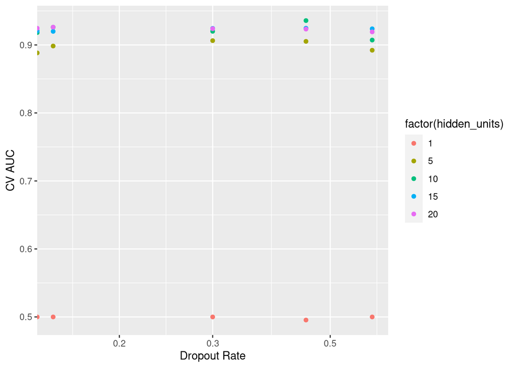

```r
mlp_fit |>
  collect_metrics() |>
  print(width = Inf) |>
  filter(.metric == "roc_auc") |>
  ggplot(mapping = aes(x = dropout, y = mean, color = factor(hidden_units))) +
  geom_point() +
  labs(x = "Dropout Rate", y = "CV AUC") +
  scale_x_log10()
```

Show the top 5 models.

```r
mlp_fit |>
  show_best("roc_auc")
```

```
# A tibble: 5 × 8
  hidden_units dropout .metric .estimator  mean     n std_err .config
         <int>   <dbl> <chr>   <chr>      <dbl> <int>   <dbl> <chr>
1           10    0.45 roc_auc binary     0.936     5  0.0216 Preprocessor1_Mod…
2           20    0.15 roc_auc binary     0.926     5  0.0177 Preprocessor1_Mod…
3           10    0.15 roc_auc binary     0.926     5  0.0143 Preprocessor1_Mod…
4           15    0.45 roc_auc binary     0.925     5  0.0171 Preprocessor1_Mod…
5           20    0    roc_auc binary     0.925     5  0.0155 Preprocessor1_Mod…
```

Let’s select the best model.

```r
best_mlp <- mlp_fit |>
  select_best("roc_auc")
best_mlp
```

```
# A tibble: 1 × 3
  hidden_units dropout .config
         <int>   <dbl> <chr>
1           10    0.45 Preprocessor1_Model18
```

**Python**

Set up CV partitions and CV criterion.

```python
from sklearn.model_selection import GridSearchCV

# Set up CV
n_folds = 5
search = GridSearchCV(
  pipe,
  tuned_parameters,
  cv = n_folds,
  scoring = "roc_auc",
  # Refit the best model on the whole data set
  refit = True
  )
```

Fit CV. This is typically the most time-consuming step.

```python
# Fit CV
search.fit(X_other, y_other)
```

```
GridSearchCV(cv=5,
             estimator=Pipeline(steps=[('col_tf',
                                        ColumnTransformer(transformers=[('num',
                                                                         Pipeline(steps=[('num_impute',
                                                                                          SimpleImputer())]),
                                                                         ['Age',
                                                                          'Sex',
                                                                          'RestBP',
                                                                          'Chol',
                                                                          'Fbs',
                                                                          'RestECG',
                                                                          'MaxHR',
                                                                          'ExAng',
                                                                          'Oldpeak',
                                                                          'Slope',
                                                                          'Ca']),
                                                                        ('cat',
                                                                         Pipeline(steps=[('cat_impute',
                                                                                          SimpleImputer(strategy='most_frequent')),
                                                                                         ('encoder',
                                                                                          OneHotEncoder(drop='first'))]),
                                                                         ['ChestPain',
                                                                          'Thal'])])),
                                       ('model',
                                        MLPClassifier(batch_size=16,
                                                      hidden_layer_sizes=8,
                                                      random_state=425,
                                                      validation_fraction=0.0))]),
             param_grid={'model__batch_size': [4, 8, 12, 16, 20, 24, 28, 32],
                         'model__hidden_layer_sizes': [1, 5, 10, 15, 20]},
             scoring='roc_auc')
```

Visualize CV results.

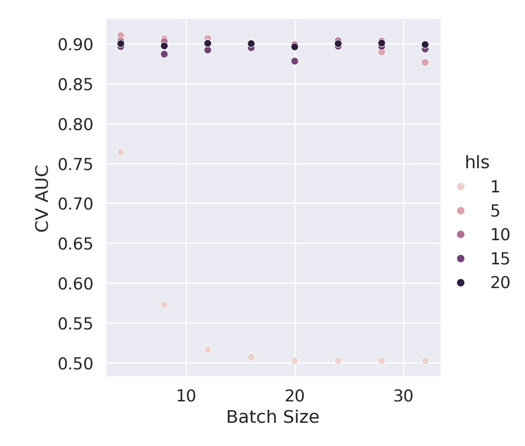

```python
cv_res = pd.DataFrame({
  "bs": np.array(search.cv_results_["param_model__batch_size"]),
  "auc": search.cv_results_["mean_test_score"],
  "hls": search.cv_results_["param_model__hidden_layer_sizes"]
  })

plt.figure()
sns.relplot(
  # kind = "line",
  data = cv_res,
  x = "bs",
  y = "auc",
  hue = "hls"
  ).set(
    # xscale = "log",
    xlabel = "Batch Size",
    ylabel = "CV AUC"
    );
plt.show()
```

Best CV AUC:

```python
search.best_score_
```

```
0.910431746031746
```

The training accuracy is

```python
from sklearn.metrics import accuracy_score, roc_auc_score

accuracy_score(
  y_other,
  search.best_estimator_.predict(X_other)
  )
```

```
0.8325991189427313
```

## 10 Finalize our model

Now we are done tuning. Finally, let’s fit this final model to the whole training data and use our test data to estimate the model performance we expect to see with new data.

**R**

```r
# Final workflow
final_wf <- mlp_wf |>
  finalize_workflow(best_mlp)
final_wf
```

```
══ Workflow ════════════════════════════════════════════════════════════════════
Preprocessor: Recipe
Model: mlp()

── Preprocessor ────────────────────────────────────────────────────────────────
5 Recipe Steps

• step_impute_mean()
• step_impute_mode()
• step_dummy()
• step_zv()
• step_normalize()

── Model ───────────────────────────────────────────────────────────────────────
Single Layer Neural Network Model Specification (classification)

Main Arguments:
  hidden_units = 10
  dropout = 0.45
  epochs = 50

Engine-Specific Arguments:
  verbose = 0

Computational engine: keras
```

```r
# Fit the whole training set, then predict the test cases
final_fit <-
  final_wf |>
  last_fit(data_split)
```

```
3/3 - 0s - 19ms/epoch - 6ms/step
3/3 - 0s - 8ms/epoch - 3ms/step
```

```r
final_fit
```

```
# Resampling results
# Manual resampling
# A tibble: 1 × 6
  splits           id               .metrics .notes   .predictions .workflow
  <list>           <chr>            <list>   <list>   <list>       <list>
1 <split [227/76]> train/test split <tibble> <tibble> <tibble>     <workflow>
```

```r
# Test metrics
final_fit |>
  collect_metrics()
```

```
# A tibble: 2 × 4
  .metric  .estimator .estimate .config
  <chr>    <chr>          <dbl> <chr>
1 accuracy binary         0.711 Preprocessor1_Model1
2 roc_auc  binary         0.842 Preprocessor1_Model1
```

**Python**

Since we called `GridSearchCV` with `refit = True`, the best model fit on the whole non-test data is readily available.

```python
search.best_estimator_
```

```
Pipeline(steps=[('col_tf',
                 ColumnTransformer(transformers=[('num',
                                                  Pipeline(steps=[('num_impute',
                                                                   SimpleImputer())]),
                                                  ['Age', 'Sex', 'RestBP',
                                                   'Chol', 'Fbs', 'RestECG',
                                                   'MaxHR', 'ExAng', 'Oldpeak',
                                                   'Slope', 'Ca']),
                                                 ('cat',
                                                  Pipeline(steps=[('cat_impute',
                                                                   SimpleImputer(strategy='most_frequent')),
                                                                  ('encoder',
                                                                   OneHotEncoder(drop='first'))]),
                                                  ['ChestPain', 'Thal'])])),
                ('model',
                 MLPClassifier(batch_size=4, hidden_layer_sizes=5,
                               random_state=425, validation_fraction=0.0))])
```

The final AUC on the test set is

```python
roc_auc_score(
  y_test,
  search.best_estimator_.predict_proba(X_test)[:, 1]
  )
```

```
0.935191637630662
```

The final classification accuracy on the test set is

```python
accuracy_score(
  y_test,
  search.best_estimator_.predict(X_test)
  )
```

```
0.8552631578947368
```